# Exploratory Analysis

## Project title

Global Population Dynamics: The Role of Birth, Death, and Life Expectancy

### Authors

Aaron Chen (chen716@uw.edu) Sam Junxuan Chen (junxuan@uw.edu) David Sung Ha Hyun (davyhyun@uw.edu)

### Date

Spring 2024 05/14/2024

### Abstract

“Our main question is understand the relationship between demographic factors such as life expectancy, birth rate, and death rate with population size. This question is important because it can provide insights into the impact of population dynamics on human well-being and societal trends. To address the question, we will analyze the correlations between these variables like life expectancy and fertility rate and their relationships.”

### Keywords

Social Science, Global Population, Population dynamics

### Introduction

Our project aims to unravel the complexity of population dynamics by investigating the relationship between different demographic factors, such as life expectancy, birth rate, and death rate, and overall population size. These factors are critical to understanding the broader consequences of demographic shifts for society structures and individual well-being. Our project raises several research questions, including: - How does life expectancy correlate with changes in population size across different regions? - What impact do variations in birth and death rates have on the population size of different countries? - Which factors, life expectancy, birth rate, death rate, or fertility rate contribute most to population?

The motivations behind these research questions are rooted in understanding how demographic shifts can influence a wide range of societal and economic outcomes. Through these questions we can assess how increases in life expectancy influence regional population structures and the associated economic and social planning needs; we can analyze how changes in birth and death rates drive population growth or decline, informing resource allocation, infrastructure development, and economic strategies; and we can identify the most impactful demographic factors on population dynamics to determine the effectiveness of different societal factors such as healthcare, education, and economic planning.

These questions are important because they address fundamental issues about human growth and social stability. Understanding these dynamics enables politicians, researchers, and public health authorities to better predict future trends and develop solutions to promote health, economic stability, and quality of life.

### Related Work

Our research examines the complex relationships between demographic characteristics such as life expectancy, birth rate, and death rate, as well as their effects on population size. This issue matters because it addresses fundamental aspects of economic, social, and health-related processes across many geographical and socioeconomic contexts. Understanding these relationships contributes in addressing concerns such as aging populations, workforce dynamics, healthcare delivery, and social security systems.

[Walker, B. H., & Brown, D. C.”Trends in lifespan variation across the spectrum of rural and urban places in the United States, 1990–2017.”](https://www.ncbi.nlm.nih.gov/pmc/articles/PMC9434220/): This study highlights the growing disparities in mortality rates and life expectancy between urban and rural areas in the U.S., emphasizing the importance of geographical differences in demographic research.

Roser, M. (2019). “Demographic transition: Why is rapid population growth a temporary phenomenon?”: Max Roser explains the concept of demographic transition through historical and contemporary examples, explaining how and why populations grow and eventually stabilize. This work is crucial for understanding the temporal dynamics of population changes and the roles that mortality and fertility rates play.

[“Main Factors Driving Population Growth”](https://www.pewresearch.org/religion/2015/04/02/main-factors-driving-population-growth/): This source delves into the primary drivers of population growth, such as fertility rates, mortality rates, age profiles, migration, and religious switching. It provides a comprehensive overview of how these factors individually and collectively influence population trends and offers projections that consider different scenarios, thereby contributing to a nuanced understanding of demographic changes.

These sources serve as a foundation for comprehending the complexities of demographic change and their worldwide repercussions. They also emphasize the importance of studying population dynamics in order to better predict future demographic transitions and develop suitable policy responses.

### The Dataset

The data was found on Kaggle. Here is the link to the data source: [Global Population Trends(2016-2022)](https://www.kaggle.com/datasets/alitaqi000/global-population-trends2016-2022). The data was collected by Syed Ali Taqi. The data compiled data from Macrotrends, [Macrotrends Offical Website](https://www.macrotrends.net/). Macrontends is a company that provides a standard stock screener and their data collection methodology is to take information from government records and integrate that data with economic data, financial market data, company expert judgment and data. The data using in the project are cited by Syed Ali Taqi from Macrontends’ data integration of Population. There are 1074 observations (rows) in the dataset.There are 12 features (columns) in the dataset. In conducting the analysis, conclusions drawn from the data may have ethical implications, especially if the conclusions contribute to the perpetuation of stereotypes or stigmatization of certain groups of the population. It is important to consider the impact that the data may have on different communities and whether the use of the data is consistent with principles of social justice and equity. A limiting factor may be the accuracy and reliability of the data, as demographic data collection methods may differ across countries and regions, leading to inconsistencies and potential bias. In addition, missing or incomplete data may affect the comprehensiveness of the analysis. In addition, demographic indicators may not fully capture the complexity of population dynamics and certain population groups like minors may be underrepresented in the data.

### Implications

If the research in our project succeeds in answering the questions posed, we believe that technicians, designers, and policymakers will be greatly affected. First, for technicians, understanding the impact of demographic factors on population dynamics can help them build models for prediction in fields such as public health, urban planning, and resource management. For designers, they can use this research to create more adaptable and sustainable living environments to meet changing demographic characteristics, such as the aging of the population that many countries in the world are now facing. Or the problem of rapid urbanization. For policymakers, they will have very comprehensive data to analyze issues such as education, health care and pensions, and can help them solve social phenomena such as overpopulation, underpopulation or an aging workforce. This multidisciplinary approach ensures that social infrastructure develops in step with demographic trends, promoting stability and prosperity.

### Limitations & Challenges

In our opinion, a significant limitation of our project is the challenge of data heterogeneity and standardization. Demographic data may be collected using different methods in different countries and regions. This can lead to inconsistencies in comparative analyses, for example, the indicators measuring birth and death rates may differ, or the definition of “urban” versus “rural” may differ. Differences in these indicators will affect the accuracy of the analysis. In addition, demographic characteristics change rapidly due to factors such as immigration, policy changes, or major economic shifts. This means that not only can the data we use be inconsistent, but it can also quickly become outdated. Therefore, any conclusions drawn must be considered within the context of limitations and are subject to the possibility of bias and error. The project will require rigorous data validation methods and adaptive approaches to accommodate and reconcile these differences to ensure findings are reliable and reflect true population dynamics.

### Summary Information

```
## $num_countries
## [1] 216
##
## $max_life_expectancy
## [1] 85
##
## $highest_birth_rate_country
## [1] "Niger"
##
## $average_population_density
## [1] 421.0012
##
## $total_urban_population
## [1] 4420979882
```

The data analysis reveals important trends across 216 countries. The highest life expectancy observed is 85 years, suggesting excellent health standards in certain areas. Niger, with the highest birth rate, highlights regions with significant population growth challenges. An average population density of 421.0011765 people per square kilometer indicates how closely people live together in various parts of the world, affecting everything from resource distribution to urban planning. The total urban population, nearing 4,420,979,882 billion, points to a major shift towards city living, with significant implications for urban infrastructure and services. This urbanization trend is critical as it shapes future planning and development strategies globally.

### Table: Global Demographic Factors (2018-2021)

| Country | Year | Total.Population | Urban.Population | Birth.Rate | Life.Expectancy |
| --- | --- | --- | --- | --- | --- |
| Afghanistan | 2018 | 36686784 | 9353296 | 36.927 | 63 |
| Afghanistan | 2019 | 37769499 | 9727157 | 36.466 | 64 |
| Afghanistan | 2020 | 38972230 | 10142913 | 36.051 | 63 |
| Afghanistan | 2021 | 40099462 | 10551772 | 35.842 | 62 |
| Albania | 2018 | 2866376 | 1728969 | 10.517 | 79 |
| Albania | 2019 | 2854191 | 1747593 | 10.343 | 79 |
| Albania | 2020 | 2837849 | 1762645 | 10.285 | 77 |
| Albania | 2021 | 2811666 | 1770478 | 10.240 | 76 |
| Algeria | 2018 | 41927007 | 30451166 | 24.074 | 76 |
| Algeria | 2019 | 42705368 | 31255632 | 23.298 | 76 |
| Algeria | 2020 | 43451666 | 32038217 | 22.431 | 74 |
| Algeria | 2021 | 44177969 | 32807002 | 21.524 | 76 |
| American Samoa | 2018 | 48424 | 42203 | 0.000 | NaN |
| American Samoa | 2019 | 47321 | 41239 | 0.000 | NaN |
| American Samoa | 2020 | 46189 | 40255 | 12.700 | NaN |
| American Samoa | 2021 | 45035 | 39257 | 0.000 | NaN |
| Andorra | 2018 | 75013 | 66058 | 7.200 | NaN |
| Andorra | 2019 | 76343 | 67170 | 7.000 | NaN |
| Andorra | 2020 | 77700 | 68311 | 0.000 | NaN |
| Andorra | 2021 | 79034 | 69438 | 0.000 | NaN |
| Angola | 2018 | 31273533 | 20488542 | 40.236 | 62 |
| Angola | 2019 | 32353588 | 21410634 | 39.725 | 62 |
| Angola | 2020 | 33428486 | 22338586 | 39.271 | 62 |
| Angola | 2021 | 34503774 | 23276246 | 38.809 | 62 |
| Antigua And Barbuda | 2018 | 91626 | 22539 | 10.816 | 79 |
| Antigua And Barbuda | 2019 | 92117 | 22574 | 11.485 | 79 |
| Antigua And Barbuda | 2020 | 92664 | 22641 | 12.160 | 79 |
| Antigua And Barbuda | 2021 | 93219 | 22727 | 12.115 | 78 |
| Argentina | 2018 | 44494502 | 40877099 | 15.187 | 77 |
| Argentina | 2019 | 44938712 | 41339571 | 14.783 | 77 |
| Argentina | 2020 | 45376763 | 41796990 | 14.125 | 76 |
| Argentina | 2021 | 45808747 | 42248949 | 13.902 | 75 |
| Armenia | 2018 | 2836557 | 1791257 | 13.307 | 75 |
| Armenia | 2019 | 2820602 | 1783156 | 12.892 | 75 |
| Armenia | 2020 | 2805608 | 1776315 | 12.455 | 72 |
| Armenia | 2021 | 2790974 | 1770343 | 12.049 | 72 |
| Aruba | 2018 | 105962 | 45999 | 9.881 | 76 |
| Aruba | 2019 | 106442 | 46351 | 9.138 | 76 |
| Aruba | 2020 | 106585 | 46574 | 8.102 | 76 |
| Aruba | 2021 | 106537 | 46734 | 7.193 | 75 |
| Australia | 2018 | 24966643 | 21474309 | 12.600 | 83 |
| Australia | 2019 | 25340217 | 21824008 | 12.100 | 83 |
| Australia | 2020 | 25655289 | 22125378 | 11.500 | 83 |
| Australia | 2021 | 25688079 | 22184739 | 12.100 | 83 |
| Austria | 2018 | 8840521 | 5153759 | 9.700 | 82 |
| Austria | 2019 | 8879920 | 5196085 | 9.600 | 82 |
| Austria | 2020 | 8916864 | 5238479 | 9.400 | 81 |
| Austria | 2021 | 8955797 | 5283472 | 9.600 | 81 |
| Azerbaijan | 2018 | 9939771 | 5534464 | 14.000 | 73 |
| Azerbaijan | 2019 | 10024283 | 5616706 | 14.100 | 73 |

Due to the large amount of incomplete data from the original data in 2017, this table will round up the 2017 data and start with 2018. This table includes life expectancy along with broader population dynamics, including birth rates, urban population, and overall population size in preparation for a deeper understanding of how demographic factors affect social outcomes.

Note that the total data includes information from 216 different countries, but here we are only displaying the top 50 rows of the table only.

### Chart 1: Population Density vs Birth Rate

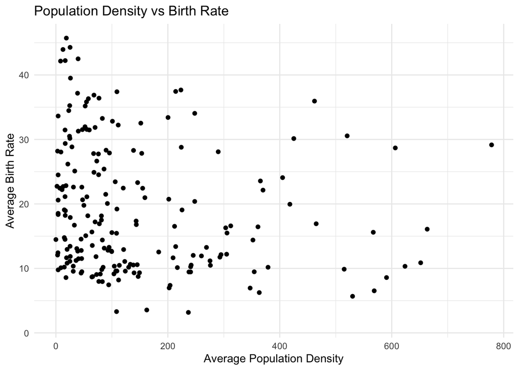

The chart “Population Density vs Birth Rate” is explores the relationship between how densely populated a country is and its birth rate. This visualization helps identify patterns that may influence policy decisions in areas like healthcare and urban planning. Observing the plot, we can see that higher population densities do not necessarily correspond to higher birth rates, suggesting influences from other various factors impact population density more significantly, not just the birth rate. The data mostly clusters at lower densities with a broad spread in birth rates, highlighting significant variance across countries.

### Chart 2: Top 5 and Bottom 5 Countries by Average Life Expectancy (2018-2021)

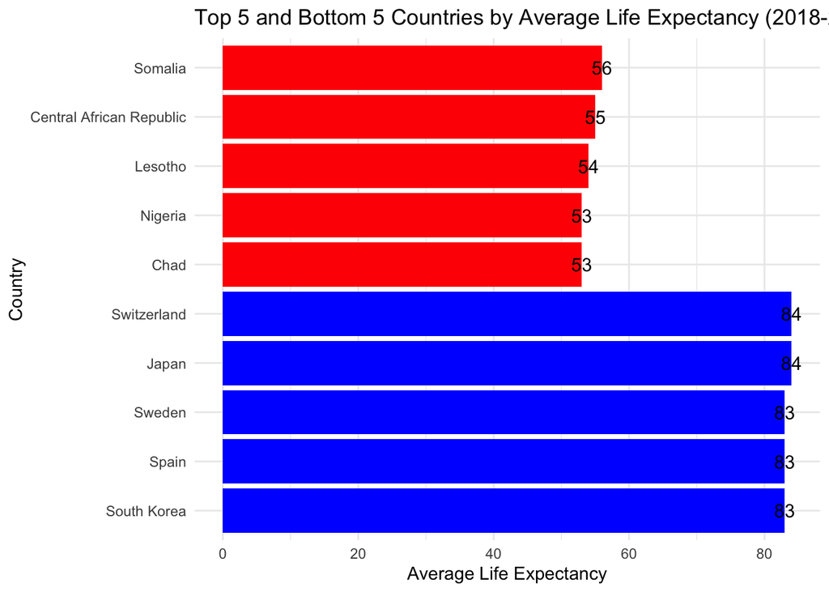

This chart shows the average life expectancy of different countries across the globe in 2018-2021, that is, how many years the population of that country will live on average. The data set lacks the population data in 2017, so this chart will skip year 2017. It shows the 5 countries with the highest life expectancy and the 5 countries with the lowest life expectancy.

#### Purpose

The purpose of this chart is to examine the variation in average life expectancy across different countries from 2018 to 2021. By identifying the top five countries with the highest life expectancy and the bottom five countries with the lowest life expectancy, we aim to gain insights into global demographic trends.

#### Insights

- The five countries with the lowest average life expectancy are all located on the African continent, and none of them has a life expectancy above 60. -These lowest ranked countries are expected to be deficient in economic stability, quality of life, local government strategic decisions, resource allocation, and social planning.
- The five countries with the highest average life expectancy are all outside the African continent, with three countries from Europe and two from Asia.
  - They are all developed countries with good education, health and social systems. However, they have the best resources, which means that the distribution of resources and social planning have a significant impact on the expected age.

### Chart 3: Total Population vs. Urban Population

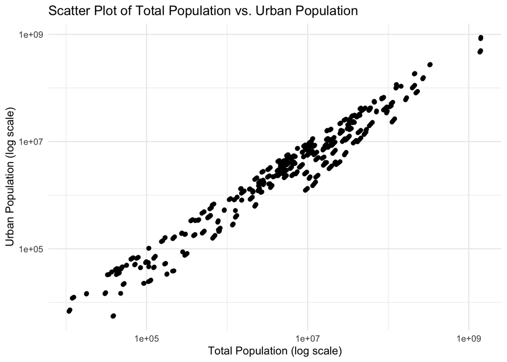

#### Purpose

I created a scatterplot of total population versus urban population to visually analyze the relationship between a country’s total population and its urban population. My main goal is to understand how the city’s population compares to the total population. This understanding is critical for policymakers, urban planners, and researchers like me who need to assess the relationship between urbanization and overall population growth.

#### Insights

The scatterplot shows a strong positive correlation between total population and urban population, indicating that as a country’s total population increases, its urban population also increases. More populous countries may have larger urban populations, perhaps due to better economic opportunities, more developed infrastructure, or active urban growth policies. However, I noticed some outliers or deviations from this trend, with some countries not having as large urban populations as expected for the overall population. These biases may stem from a variety of factors, such as geographical constraints, different stages of economic development, or specific national policies affecting urban development.